# Airbnb Zurich

ESSHA KHAN

Open to opportunities

← All projects

Airbnb Zurich  
Data Mining & Analysis Project

01 DATA MINING PROJECT

# What shapes price, demand, and listing performance in Zurich's Airbnb market?

I analyzed Airbnb listings across Zurich to understand how neighborhood, room type, capacity, host quality, and booking behavior shape the market — then tested whether machine-learning models could uncover additional patterns in amenities, pricing, and listing segments.

PythonPandasData Cleaning VisualizationKNNDistilBERTK-Means

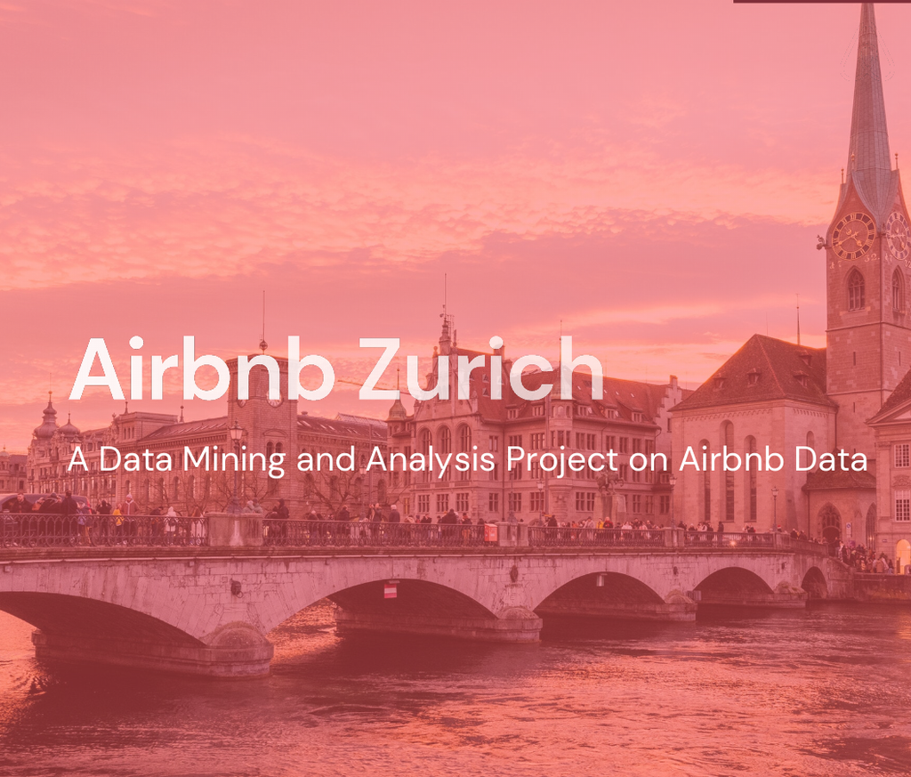

PROJECT QUESTIONS

## What did I want to understand?

01 — MARKET

### Where is Airbnb demand strongest?

Compare neighborhoods using price, booking activity, reviews, ratings, and room-type mix.

02 — PRICING

### What appears to drive higher prices?

Examine listing capacity, location, property characteristics, and the variation that remains within similar listings.

03 — HOST QUALITY

### How does hosting quality vary?

Explore superhost concentration and whether high-demand central areas show more professionalized hosting.

04 — MACHINE LEARNING

### Can models reveal useful listing patterns?

Test classification, transformer-based text modeling, and clustering on different aspects of the Zurich market.

02 PROCESSING & CLEANING

## Preparing a messy marketplace dataset for analysis

I treated missing values based on the meaning of each variable rather than applying one blanket imputation rule. Missing bathrooms, bedrooms, and beds were inferred using related listing information such as guest capacity; host response variables were cleaned and encoded; extreme bed and bedroom values were handled before modeling; text nulls were converted to empty strings for compatibility; and low-information or heavily missing fields were removed.

01**Audit missingness**

02**Context-aware imputation**

03**Clean & encode fields**

04**Handle extreme values**

05**Remove low-value features**

03 MARKET INSIGHTS

## Pricing, ratings, reviews, demand & booking behavior

### Airbnb Market Insights — Zurich

Pricing, ratings & reviews across top 10 neighborhoods

**CHF 267.86**Highest Avg. Price · Rathaus

**4.83**Highest Avg. Rating · Unterstrass

**72.95**Most Reviews (Avg.) · Rathaus

**CHF 1,624.98+**Widest Price Range · Top 10

**1. Average Airbnb Price for Top 10 Neighborhoods in Zurich**

**2. Price Distribution for Top 10 Neighborhoods in Zurich (Mean + Variability)**

**3. Average Guest Rating for Top 10 Neighborhoods in Zurich**

**4. Average Number of Reviews by Top 10 Neighborhoods in Zurich (Demand Proxy)**

#### Interpretation

The combination of high prices, strong ratings, and review activity suggests that Zurich's central and established Airbnb areas can sustain premium pricing while still attracting substantial demand. At the same time, the broad price distributions show that neighborhood is not the only driver: room type, property quality, capacity, and amenities likely explain part of the variation within each area.

### Airbnb Demand & Booking Insights — Zurich

Demand, booking behavior & market gaps across top 10 neighborhoods

**52.54%**Highest Fully Booked Share · Unterstrass

**0.18**Largest Demand Gap · Oerlikon

**78.40%**Highest 30-Day Booking Rate · Unterstrass

**68.80%**Highest 365-Day Booking Rate · Unterstrass

**1. Share of Fully Booked Listings by Top 10 Neighborhoods in Zurich**

**2. Short-Term vs Long-Term Demand Gap by Neighborhood**

**3. Short-Term vs Long-Term Booking Rates by Neighborhood**

#### Demand findings

- Unterstrass leads short-term demand with a 52.54% fully booked share and the highest 30-day booking rate at 78.40%.
- Oerlikon has the largest short-term versus long-term demand gap at 0.18, suggesting relatively stronger near-term demand.
- Rathaus has the highest review volume, making it the most established and popular area by this demand proxy.

#### Market context

Neighborhoods do not behave uniformly across booking horizons. Alt-Wiedikon and Altstetten remain strong across both short- and long-term booking measures, while other areas show a more pronounced near-term lift. This supports treating Zurich as a collection of distinct micro-markets rather than a single homogeneous rental market.

04 DATA VISUALIZATIONS

## A closer look at listing structure, hosts, and pricing

#### Room Type Distribution by Neighborhood

#### What it shows

- Entire homes/apartments dominate listings across most neighborhoods.
- Private and shared rooms appear more in select areas rather than being evenly distributed throughout Zurich.

#### Real-world context & insight

Central areas such as Langstrasse, Seefeld, and Altstadt contain more entire-home rentals, consistent with tourist and business demand. Peripheral neighborhoods show relatively more private/shared-room supply, which is more affordability-focused. Overall, the market is premium-skewed, with full-property rentals dominating high-demand zones.

#### Percentage of Superhosts by Neighborhood

#### What it shows

- There is significant variation in superhost percentages across neighborhoods.
- Central and high-demand areas show higher concentrations of superhosts.

#### Zurich context & insight

City / Altstadt is tourism-heavy and highly competitive, encouraging hosts to optimize quality, while upscale Seefeld is associated with more professional hosting standards. Outer residential areas show lower superhost rates and more casual hosting. The broader pattern suggests that high-demand central neighborhoods push hosts toward higher service quality and professionalism.

#### Insight

Capacity contributes to price, but the large vertical spread among listings with the same guest capacity indicates that location, amenities, room type, and property quality are important premium-pricing drivers. The pattern reinforces why the later models use multiple structured and unstructured features rather than relying on size alone.

05 MACHINE LEARNING

## KNN classification and transformer-based text modeling

The machine-learning section retains the detailed evaluation information from the presentation: target balance, predictors, model configuration, confusion matrix, classification report, baseline comparison, transformer training history, evaluation metrics, and an example prediction.

### KNN Classification: Predicting Parking Availability

Goal: use k-nearest neighbors to predict whether a rental has parking.

#### AMENITY CHOSEN

Parking

**Has Parking** 52.2%

**No Parking** 47.8%

#### PREDICTORS (FEATURES)

Accommodates

Bathrooms

Bedrooms

Beds

Price

#### MODEL CONFIGURATION

Algorithm

**K-Nearest Neighbors (KNN)**

Best K (Optimal)

7

#### MODEL PERFORMANCE

Accuracy

0.58

|  | Pred 0 | Pred 1 |
| --- | --- | --- |
| Actual 0 | 134 | 106 |
| Actual 1 | 107 | 160 |

#### Classification report

| Class | Precision | Recall | F1 | Support |
| --- | --- | --- | --- | --- |
| 0 (No Parking) | 0.56 | 0.56 | 0.56 | 240 |
| 1 (Has Parking) | 0.60 | 0.60 | 0.60 | 267 |
| Macro Avg | 0.58 | 0.58 | 0.58 | 507 |
| Weighted Avg | 0.58 | 0.58 | 0.58 | 507 |

#### Baseline comparison

~0.53

The majority-class baseline always predicts the most frequent class from the training data. KNN reaches 0.58, only modestly above the naive baseline, which indicates limited predictive power from these basic listing features.

#### Model interpretation

The target is close to balanced, so the 0.58 accuracy is not being created by an overwhelmingly dominant class. Precision, recall, and F1 are also fairly even across the two classes, but all remain around the high-0.50 range. This means the model is not reliably separating listings with parking from listings without parking.

#### Key takeaway

Parking availability is not strongly explained by accommodates, bathrooms, bedrooms, beds, and price alone. Location, property type, and richer amenity information may carry more useful signal and would be natural additions in a stronger model.

### Transformer Model: Predicting Price Quartile from Text

DistilBERT Base Uncased · multi-class classification from Q1 (lowest) to Q4 (highest)

#### MODEL OVERVIEW

**DistilBERT Base Uncased**  
(Hugging Face)

**Task:** predict price quartile Q1 → Q4.

**Input text columns**

description

host_about

amenities

#### TRAINING RESULTS

| Epoch | Train Loss | Val Loss | Accuracy |
| --- | --- | --- | --- |
| 1 | No log | 1.263177 | 0.408284 |
| 2 | 1.256944 | 1.212910 | 0.441815 |

Validation lossValidation accuracy

**Best model after 2 epochs:**  
Validation Loss 1.2129 · Accuracy 0.4418

#### EVALUATION SUMMARY

| Metric | Result |
| --- | --- |
| Evaluation loss | 1.2129 |
| Evaluation accuracy | **0.4418** |
| Runtime | 4.8767 s |
| Samples / sec | 103.963 |
| Steps / sec | 13.123 |
| Epoch | 2.0 |

FINAL VALIDATION ACCURACY

44.18%

#### EXAMPLE PREDICTION

“Beautiful luxury apartment in central Zurich with modern design, large balcony, and premium amenities. Host is very responsive and provides excellent service. Includes wifi, kitchen, washer, dryer, and parking.”

Predicted Quartile

Q4_high

#### Training behavior

From epoch 1 to epoch 2, validation loss decreased from 1.263177 to 1.212910 while validation accuracy increased from 0.408284 to 0.441815. That movement suggests the model was learning useful textual patterns during the reported training window rather than simply memorizing noise.

#### Key takeaway

The transformer captures meaningful price-related signal from description, host biography, and amenities, but 44.18% validation accuracy leaves substantial room for improvement. The presentation identifies more data, stronger preprocessing, and hyperparameter tuning as the next opportunities.

06 CLUSTERING ANALYSIS

## Segmenting Zurich Airbnb listings into five market profiles

K-Means clustering uses price, accommodates, number of reviews, review score, and the Booked 30 demand proxy. Missing values were handled with median imputation; zero ratings were excluded because they represent no reviews; and Booked_30 was created as 1 − Availability_30 / 30.

#### Features Used

Price (CHF)

Accommodates (Guests)

Number of Reviews

Review Scores Rating (1–5)

Booked 30 (Demand Proxy)

| Cluster | Profile | Price | Guests | Reviews | Rating | Booked 30 |
| --- | --- | --- | --- | --- | --- | --- |
| 0 | Budget High-Occupancy Listings | 120.72 | 1.93 | 18.56 | 4.85 | 0.93 |
| 1 | Mid-Price Low-Demand Listings | 204.73 | 2.33 | 15.58 | 4.82 | 0.24 |
| 2 | High-Reputation High-Demand Listings | 144.10 | 3.25 | 295.38 | 4.73 | 0.74 |
| 3 | Premium Large-Capacity Listings | 324.21 | 4.80 | 23.08 | 4.84 | 0.79 |
| 4 | Lower-Rated Mid-Range Listings | 146.48 | 2.65 | 8.26 | 3.78 | 0.70 |

#### Average Price and Demand Profile by Airbnb Cluster

Budget

Mid-Price

High-Rep

Premium

Lower

Average Price (CHF)

#### Number of Listings in Each Cluster

*579*Mid-Price Low-Demand

*1,168*Budget High-Occupancy

*89*High-Reputation

*554*Premium Large-Capacity

*134*Lower-Rated

#### Average Price by Airbnb Cluster

*120.72*Budget

*204.73*Mid-Price

*144.10*High-Reputation

*146.48*Lower-Rated

*324.21*Premium

Cluster

#### How the clusters differ

- **Budget High-Occupancy:** small, lower-priced listings with very high short-term booking rates.
- **Mid-Price Low-Demand:** smaller listings with relatively higher prices but low booking rates.
- **High-Reputation High-Demand:** moderate prices, extremely high review counts, and strong booking rates.
- **Premium Large-Capacity:** larger, high-priced listings with strong booking rates.
- **Lower-Rated Mid-Range:** mid-range listings with lower review scores and fewer reviews.

#### Strategic interpretation

The clusters separate Zurich's Airbnb supply along more than one dimension: price, capacity, popularity, satisfaction, and demand. This makes the segmentation more actionable than a price-only grouping. The five profiles can support differentiated pricing, marketing, positioning, and host-support strategies for very different types of listings.

07 KEY TAKEAWAYS

## What did the analysis suggest?

MARKET STRUCTURE

### Location matters

Central areas combine stronger demand with higher prices, while outer neighborhoods tend to be more affordable and lower-demand.

PRICING

### Size helps, but does not explain everything

Capacity is positively related to price, but location, room type, amenities, and listing quality also contribute to the spread.

DEMAND

### Short-term demand is uneven

Booking activity differs across neighborhoods, with some central areas showing substantially stronger near-term demand.

LISTINGS

### Entire homes dominate

The Zurich market is heavily oriented toward entire-home rentals, particularly in central and higher-demand areas.

MODELING

### Predictive signal was mixed

KNN and transformer experiments found some signal, but neither selected feature set fully explained the target outcomes.

SEGMENTATION

### Five profiles reveal market structure

Clustering separated budget, high-demand, premium, and larger-capacity listing profiles with different strategic characteristics.